# MovieLens Rating Prediction: A regularized Bias Model with Iterative Coordinate Descent

Aaric

mai 11, 2026

# 1 Introduction & Overview

## 1.1 Project Background

This report presents the methodology, implementation, and results of a movie rating prediction system developed for the Harvard Data Science Capstone. The objective is to build a model that predicts user ratings on the MovieLens dataset with the lowest achievable Root Mean Squared Error (RMSE).

The MovieLens dataset contains approximately 10 million ratings submitted by users for a large catalogue of films. Each rating record contains a user identifier, a movie identifier, a numerical rating (0.5 to 5.0 in 0.5 increments), a Unix timestamp, a movie title, and one or more genre labels.

## 1.2 Objective

The primary goal is to predict the rating $\hat{r}_{u,i}$ that user $u$ would assign to movie $i$, minimising the RMSE defined as:

$$\text{RMSE} = \sqrt{\frac{1}{N}
\sum_{u,i} \left(\hat{r}_{u,i} - r_{u,i}\right)^2}$$

where $r_{u,i}$ is the true observed rating and $N$ is the total number of predictions.

## 1.3 Approach Summary

The model extends a regularized baseline approach — starting from the global mean rating and sequentially estimating bias terms for movie, user, year, month, week, and genre effects. Bias estimates are obtained through iterative coordinate descent, where all effects are updated in turn and the process repeats until convergence, producing stable and robust estimates.

# 2 Methods & Model Description

## 2.1 Data Partitioning

The `edx` dataset is split into a training set (90%) and a held-out test set (10%) using stratified sampling via `createDataPartition`, with a fixed seed for reproducibility.

Cold-start entries (users or movies appearing only in the test set) are handled implicitly: missing bias values are imputed with zero, causing predictions to fall back to the global mean or any available partial bias.

## 2.2 Feature Engineering

Three temporal features are extracted from the Unix timestamp using `floor_date` (rather than `round_date`) to avoid attributing ratings to future time periods. Genre labels, originally stored as pipe-delimited strings, are parsed into individual genre tokens. A per-rating weight of $1/n_\text{genres}$ is assigned so that a rating’s total genre contribution sums to 1 regardless of how many genres a movie belongs to. A stable `row_id` is assigned immediately after feature engineering and preserved throughout all subsequent operations to ensure correct joins.

## 2.3 Baseline Model

The simplest possible predictor is the global mean rating $\mu$ computed over the training set:

$$\hat{r}_{u,i} = \mu$$

This serves as the performance baseline against which all model improvements are measured.

## 2.4 Regularized Bias Model

The full prediction is formulated as a sum of the global mean and six additive bias terms:

$$\hat{r}_{u,i} = \mu + b_i + b_u + b_y +
b_m + b_w + b_g$$

where:

| Term | Description |
| --- | --- |
| $\mu$ | Global mean rating |
| $b_i$ | Movie bias — captures whether a film is rated above or below average |
| $b_u$ | User bias — captures individual rating tendencies |
| $b_y$ | Year bias — captures year‑level temporal trends |
| $b_m$ | Month bias — captures month‑level seasonal patterns |
| $b_w$ | Week bias — captures week‑level fluctuations |
| $b_g$ | Genre bias — captures genre preference patterns (weighted) |

Each bias term is estimated using regularized least squares. For a generic effect $b_x$ with regularization parameter $\lambda$:

$$b_x = \frac{\sum_{j \in S_x}
r_j^*}{|S_x| + \lambda}$$

where $r_j^*$ is the residual after removing all other known effects, and $S_x$ is the set of ratings belonging to group $x$. Larger $\lambda$ shrinks estimates for groups with few observations toward zero, guarding against overfitting on rare movies, users, or time bins.

The genre bias is computed at the level of individual genre tokens. Each rating’s genre contribution is the weighted sum of the bias values of all genres it belongs to:

$$b_g^{(j)} = \sum_{g \in G_j} w_j \cdot
b_g$$

where $w_j = 1/n_{\text{genres},j}$ and $G_j$ is the set of genres for rating $j$. This is implemented via an unnested genre table joined back to the rating level, avoiding `rowwise()` iteration entirely.

## 2.5 regularization Parameter Tuning

The regularization parameter $\lambda$ is selected via a held-out validation split of the training set (80% training, 20% validation). For each candidate value in $\lambda \in \{1, 1.5, 2, \ldots, 10\}$, all six bias terms are estimated on the training portion and evaluated on the validation portion. The $\lambda$ minimising validation RMSE is retained for final model training.

## 2.6 Iterative Coordinate Descent

Rather than estimating each bias term in a single sequential pass, the model employs iterative coordinate descent: all six bias terms are updated in turn, each time conditioning on the current estimates of all other terms. This process repeats until the change in training RMSE falls below a convergence tolerance of $10^{-5}$ or a maximum of 30 iterations is reached.

At each iteration, all current bias values are joined onto the training data to form a base table. Each effect is then updated by computing the residual after removing the contributions of all other effects, and applying the regularized sum formula. The genre effect is handled by joining through the unnested genre table and re‑aggregating to the rating level.

# 3 Code Engineering & Design Decisions

## 3.1 Reusable Functions

Three operations are needed in multiple places — feature engineering, genre contribution lookup, and full prediction assembly. Each is encapsulated in a named function (`add_features()`, `compute_genre_contrib()`, `build_predictions()`). This follows the DRY principle and ensures consistency.

## 3.2 Stable Row Identity

A unique, stable integer identifier `row_id` is stamped once at the source (immediately after feature engineering) and never reassigned. It serves as the join key that reconnects unnested genre rows back to their parent rating. This prevents the latent bug of generating new row IDs inside a function after the data has been reordered.

## 3.3 Vectorised Genre Handling

Instead of using `rowwise()` loops (which are extremely slow on large data), the script expands the genre list to one row per genre token, performs vectorised joins, and then aggregates back to the rating level. This uses optimised C‑level operations and runs orders of magnitude faster.

## 3.4 Pre‑allocation & Hoisting

Result containers are pre‑allocated with their final length to avoid repeated memory reallocation. The expensive unnesting operation is performed once outside the training loop and reused across all iterations.

## 3.5 NA Imputation for Cold‑Start

Missing bias values after `left_join` are replaced with zero, so that unseen users, movies, or genres fall back to the global mean plus any available partial information.

## 3.6 Reproducibility

After training, the model is saved not only as raw bias tables but also as a **closure** (a function that carries all bias values inside it). The `make_predictor()` function captures the global mean $\mu$ and the six bias tables, and returns a single function `predict_ratings()`.

This predictor function: - Takes a data frame with columns `userId`, `movieId`, `timestamp`, `genres`. - Automatically performs feature engineering (temporal binning, genre splitting, weighting). - Joins all pre‑computed bias terms (coalescing missing values to zero). - Returns a vector of predicted ratings.

The predictor is saved as an `.rds` file (`predict_ratings.rds`). Loading it with `readRDS()` restores a fully functional prediction function – no retraining, no repeated code, and no risk of inconsistent feature engineering.

**Example usage:**

```r
predict_ratings <- readRDS("../RESULTS/predict_ratings.rds")

new_ratings <- data.frame(
  userId    = c(343, 233),
  movieId   = c(1123, 1123),
  title = c("Perfect Candidate, A (1996)","Perfect Candidate, A (1996)"),
  timestamp = c(974595468, 974595468),
  genres    = c("Documentary", "Documentary")
)

predictions <- predict_ratings(new_ratings)
new_ratings$p_rating <- round(predictions,2)
new_ratings$r_rating <- round(round(predictions, 1)/0.5)*0.5


knitr::kable(
  new_ratings,
  caption = "Predictions using the deployment‑ready predictor",
  col.names = c("userId", "movieId","title", "timestamp", "genres","p_rating", "r_rating"),
  align = c("l", "l", "c","c", "c", "r","r")
)
```

[output not shown]

# 4 Results & RMSE

## 4.1 Baseline Performance

The global mean predictor achieves an RMSE of **1.0601** on the test set.

## 4.2 Lambda Tuning Results

The optimal regularization parameter was found to be **5**, which minmizes the validation RMSE as shown below.

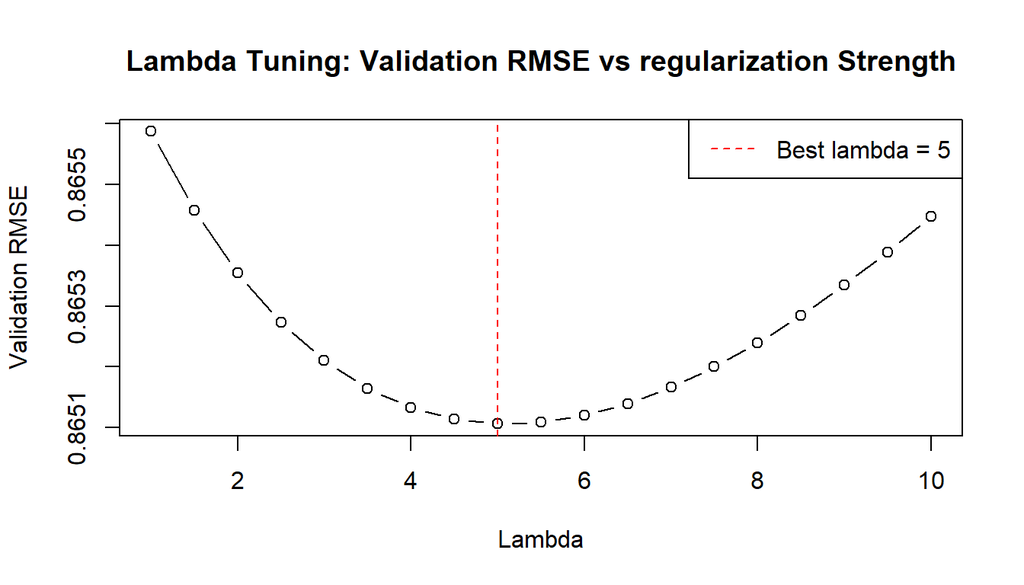

## 4.3 Step-by-Step RMSE Improvement

The table below shows the RMSE on the test set as each bias term is added incrementally, demonstrating the individual contribution of every effect.

Test RMSE after adding each bias term

| Model Step | Test RMSE | RMSE Reduction |
| --- | --- | --- |
| Baseline (global mean) | 1.0601 | 0.0000 |
| + Movie bias | 0.9449 | 0.1152 |
| + User bias | 0.8643 | 0.0805 |
| + Year bias | 0.8632 | 0.0011 |
| + Month bias | 0.8629 | 0.0004 |
| + Week bias | 0.8623 | 0.0005 |
| + Genre bias | 0.8623 | 0.0001 |

## 4.4 Final Model Performance

After iterative coordinate descent training with the selected $\lambda$, the model is evaluated on the held‑out test set. The final test RMSE is **0.8623**.

## 4.5 Interpreting the RMSE Table: Task‑Dependent Decisions

```
The improvement column shows how much each bias term reduces RMSE *under a random split where all movies appear in both training and test sets*. However, the optimal model differs by deployment task. Use this decision map to avoid “RMSE delusion” – treating the numbers as absolute.
```

Task‑dependent interpretation of the RMSE table

| Task | What | Action |
| --- | --- | --- |
| **Static catalogue** (same movies, only new ratings) | Movie and user biases dominate; genre adds near‑zero. | Keep effects above a threshold (e.g., 0.0004). Drop genre bias – it adds no value. Model stays simple and fast. |
| **Cold‑start** (new, unseen movies) | The table *underestimates* genre because movie bias steals its signal. | **Cannot rely on this table.** Build a separate evaluation: hold out entire movies. Then genre bias will likely show large improvement. |

## 4.6 Summary Table

Model performance on the held-out test set

| Model | Test RMSE | Improvement over Baseline (%) |
| --- | --- | --- |
| Baseline (global mean) | 1.0601 | — |
| regularized Bias Model (Coordinate Descent) | 0.8623 | 18.66 |

# 5 Visualizations & Plots

## 5.1 Rating Distribution

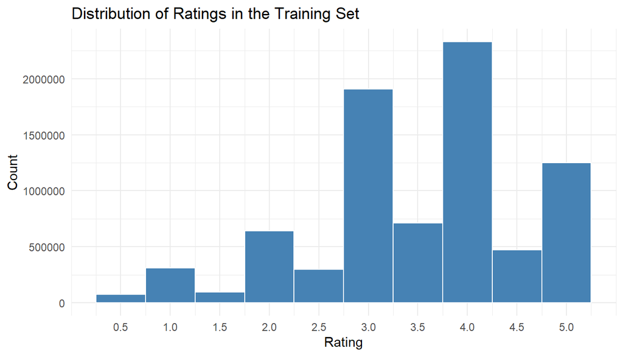

## 5.2 Ratings per Movie (Log Scale)

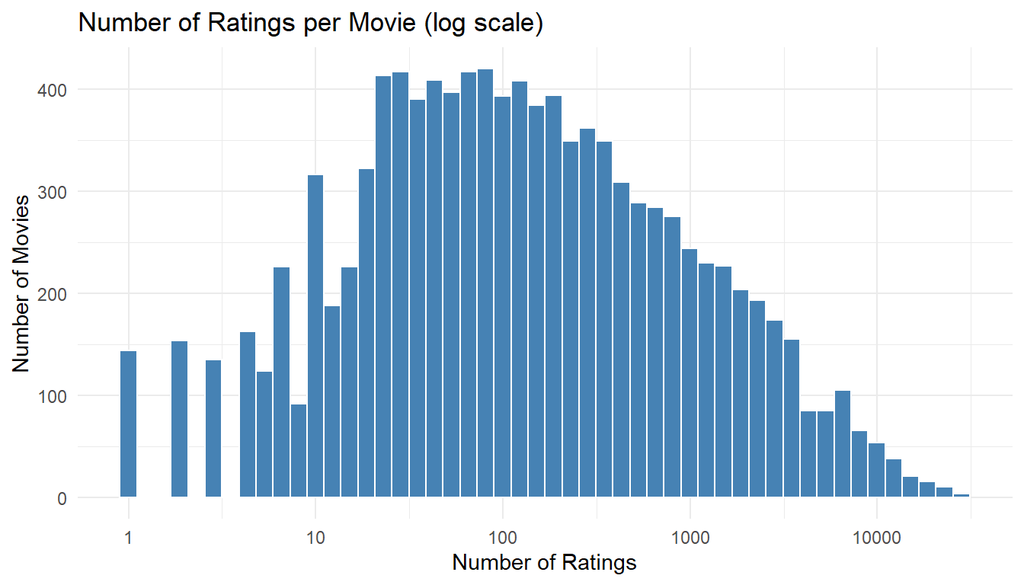

## 5.3 Average Rating Over Time (Year)

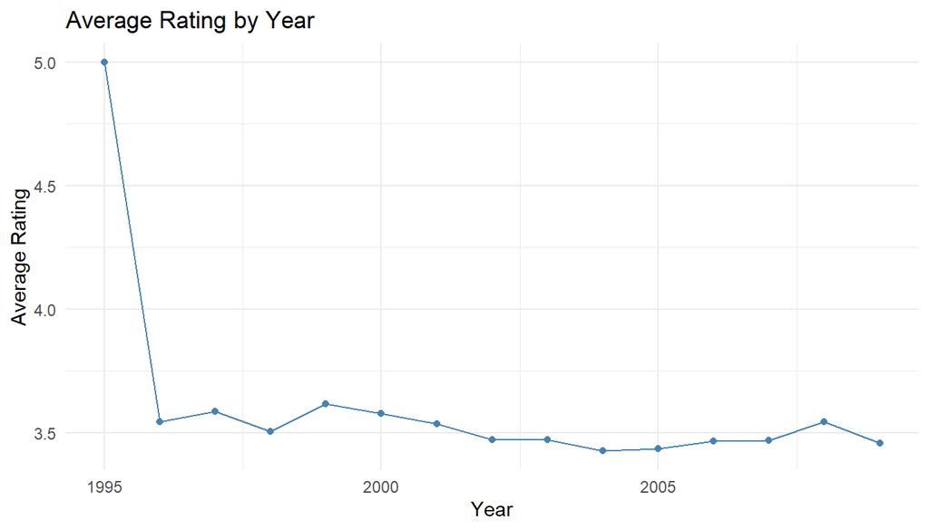

## 5.4 Top Movie Biases

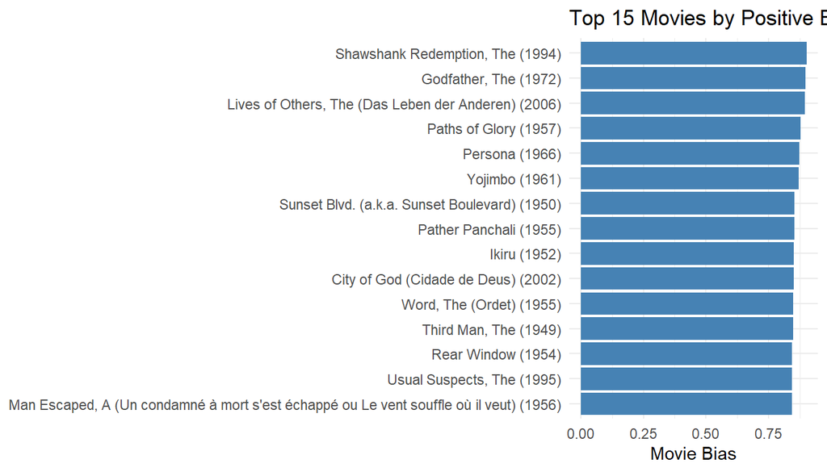

## 5.5 Genre Bias

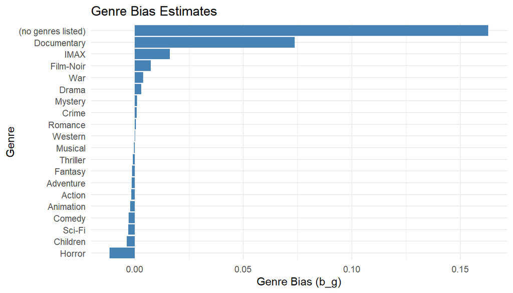

## 5.6 Residual Distribution

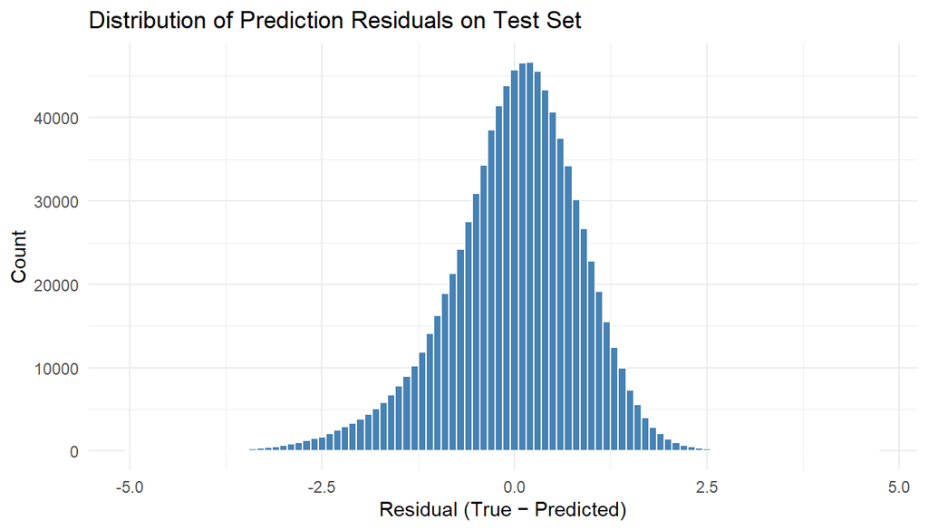

## 5.7 Residuals vs Predicted (Diagnostic)

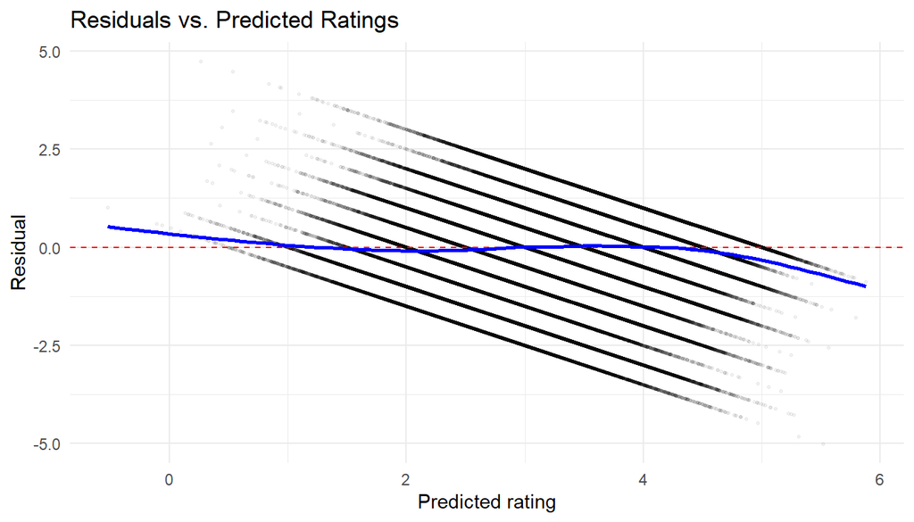

# 6 Conclusion

## 6.1 Summary

This project developed a regularized additive bias model for movie rating prediction on the MovieLens dataset. Starting from a global mean baseline (RMSE = 1.0601), the final model trained via iterative coordinate descent achieves a test RMSE of 0.8623 — an improvement of 18.66% over the baseline. The step-by-step analysis shows that movie and user biases account for the largest RMSE reductions, with genre and temporal effects contributing additional gains. All estimates are regularized with an optimally tuned $\lambda$ and converge to a stable solution through iterative updates.

### 6.1.1 The Danger of RMSE Delusion

Due to the bias absorption by movie_bias a single RMSE number from a standard random split can be misleading if interpreted without considering the deployment task. For a static catalogue (predicting ratings for the same set of movies), dropping negligible biases like genre (0.0001 improvement) does not hurt accuracy. For a cold‑start system (recommending new movies), genre becomes critical – but its value is invisible in the standard table because movie bias already absorbs genre signal.

Therefore, always ask: *What is the intended use case?* Then design the evaluation protocol and model accordingly. The step‑wise RMSE table is a tool, not a verdict. in general the Step-by-Step RMSE Improvement table is a representative of the base the model was been built for and doesn’t mean genre isn’t a valuable feature we can use to forecast the rating perhaps it could be very useful feature if the task change even if the RMSE scale show it’s not

## 6.2 Limitations

The model is linear and additive, missing potential interaction effects (e.g., a user who specifically loves action films). Temporal effects (year, month, week) contribute modestly compared to movie and user biases.

## 6.3 Potential Extensions

- **Deployment ready:** The saved predictor function allows easy integration into a production environment (e.g., a Shiny app or API) without any R Markdown or training code.
- Matrix factorisation (SVD/ALS) to capture latent user‑item interactions.
- More granular temporal dynamics (e.g., drifting user biases over time).
- Ensemble with a latent factor model.

*Report generated using R Markdown. All analysis was performed in R using the `tidyverse`, `data.table`, `caret`, and `lubridate` packages. Results are based on pre‑computed outputs from the final model script.*